# Week 6: Fitting Models and Stochasticity

EFB 370 - Spring 2023

Dr. Gurarie and Katya Khadonova

2023-02-23

```r
SeaOtters <- read.csv("../data/SeaOtters.csv")
SeaLions <- read.csv("../data/SeaLions.csv")
```

# Part I: Fitting linear models

## Sea Lion Body Sizes

You can extract the length and weight of the sea lion pups and plot the Weight against Length as follows:

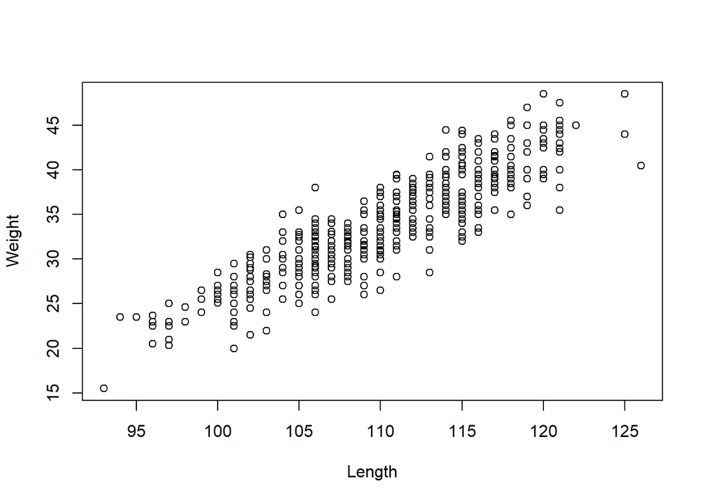

```r
Length <- SeaLions$Length
Weight <- SeaLions$Weight
plot(Length, Weight)
```

But, a **better, cleaner** way to do this is with the “~” (tilde) syntax. Here we’re putting the “response” variable (Weight) against the “predictor” (Length), and the data frame is `SeaLions`:

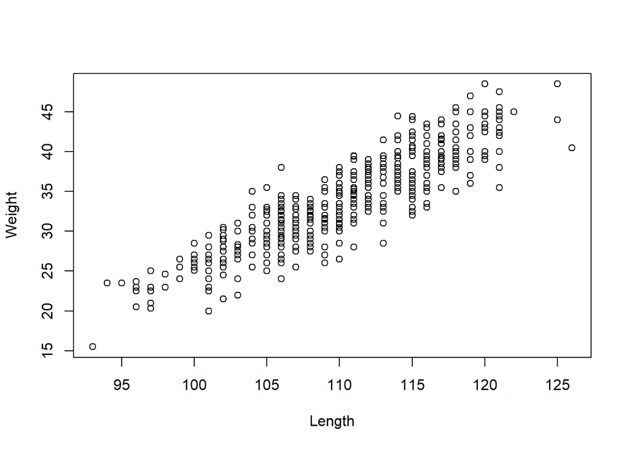

```r
plot(Weight ~ Length, data = SeaLions)
```

**NOTE: You can skip the section below as it is non-essential. But arguably “fun”.**

### `ggplot` and installing packages

Or, if you like, you can use the fancy-shmancy `ggplot` function to make plots. But you have to install a new “library” called `ggplot2`. To install a library, you use the `install.packages()` function:

```r
install.packages("ggplot2")
```

You only need to install a package once on your computer. After that, it will always be there.

Alternatively, you can use the `R` interface to install new packages. To do so:

- Click the `Packages` tab in the bottom right window of `Rstudio` and click `Install`
- … or … go to `Tools > Ìnstall Packages` in the menu bar.
- In the blank “packages” line, start typing the name of the package you want. `RStudio` should automatically fill this in with suggestions. Use a comma to separate the names of multiple package if installing more than one simultaneously.
- Click `Install`. This will automatically put the correct code in the console for you.

From now on, whenever you need that package loaded you use the `library` function. You only have to do this once each time you open `R`, after that, a package stays in your library for the rest of your session.

```r
library(ggplot2)
```

If you receive prewritten code from someone and open the file in `RStudio`, the software will automatically identify packages called by the `library` funtion. If you do not have these packages installed, `Rstudio` will ask you if you’d like to install them, which can save you time. However, you will still need to run the `library` function on each package before you can use them.

Now - **finally** - you have access to the funky / fancy library of ggplotting functions.

```r
require(ggplot2)
```

The ggplot function allows for some more flexible plotting, but (at least initialy) with more complicated syntax. For example, the equivalent of the plot above is:

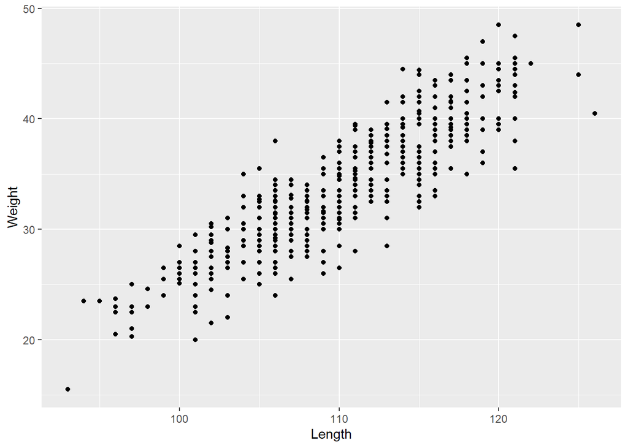

```r
ggplot(SeaLions, aes(x = Length, y = Weight)) + geom_point()
```

Now it is easy to, for example, add sex:

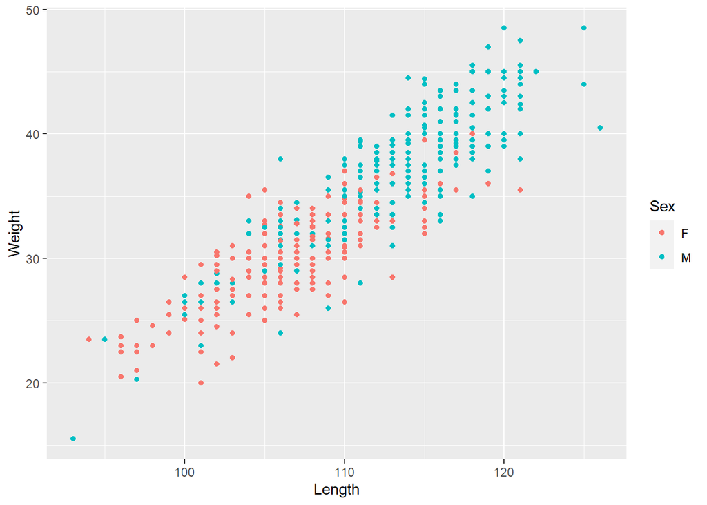

```r
ggplot(SeaLions, aes(x = Length, y = Weight, color = Sex)) + geom_point()
```

And to do other nifty tricks. But for now, sticking to the so-called base plots is easier.

## Fitting a linear model

Look closely at the `plot` command above:

```r
plot(Weight ~ Length, data = SeaLions)
```

This is the *exact* syntax you need to fit a linear model with the `lm()` function, which fits a linear regression. That means it finds the “best” values for a model that looks likes this:

$$Y_i = \alpha + \beta\, X_i +
\epsilon_i$$

Where $Y$ is the response variable, $X$ is the predictor, $\alpha$ is the intercept, $\beta$ is the slope, and $\epsilon$ is the “residual” variation, i.e. a random variable: ${\cal N}(0, \sigma^2)$.

```r
lm(Weight ~ Length, data = SeaLions)
```

```
##
## Call:
## lm(formula = Weight ~ Length, data = SeaLions)
##
## Coefficients:
## (Intercept)       Length
##    -59.5108       0.8468
```

If you just run this, you will see the output, which is just the estimate of the intercept and the slope (i.e. the Length effect). Think about how to interpret these numbers.

However, there is actually a lot more information in this linear model fit. But to get to it, you need to **save the linear model output** into a new object. Thus:

```r
sealion.fit <- lm(Weight ~ Length, data = SeaLions)
```

Now you can learn more:

```r
summary(sealion.fit)
```

```
##
## Call:
## lm(formula = Weight ~ Length, data = SeaLions)
##
## Residuals:
##     Min      1Q  Median      3Q     Max
## -7.6832 -1.7238  0.0668  1.9294  7.7447
##
## Coefficients:
##              Estimate Std. Error t value Pr(>|t|)
## (Intercept) -59.51078    2.22651  -26.73   <2e-16 ***
## Length        0.84685    0.02024   41.84   <2e-16 ***
## ---
## Signif. codes:  0 '***' 0.001 '**' 0.01 '*' 0.05 '.' 0.1 ' ' 1
##
## Residual standard error: 2.663 on 496 degrees of freedom
## Multiple R-squared:  0.7792, Adjusted R-squared:  0.7788
## F-statistic:  1750 on 1 and 496 DF,  p-value: < 2.2e-16
```

Most important, the standard errors, p-values (especially on the slope) and R^2 values.

There are usually a few questions in a statistical model.

```r
(CI.low <- 0.84675 - 2*0.02024)
```

```
## [1] 0.80627
```

```r
(CI.high <- 0.84675 + 2*0.02024)
```

```
## [1] 0.88723
```

So the point estimate and 95% CI are **0.847 (0.806, 0.887)**.

You *can* also extract those numbers from the linear model fit as follows:

```r
summary(sealion.fit)$coef[2,1] + c(-2,2) * summary(sealion.fit)$coef[2,2]
```

```
## [1] 0.8063681 0.8873311
```

### Plotting the fit

If you have a linear model, you can easily plot the fit:

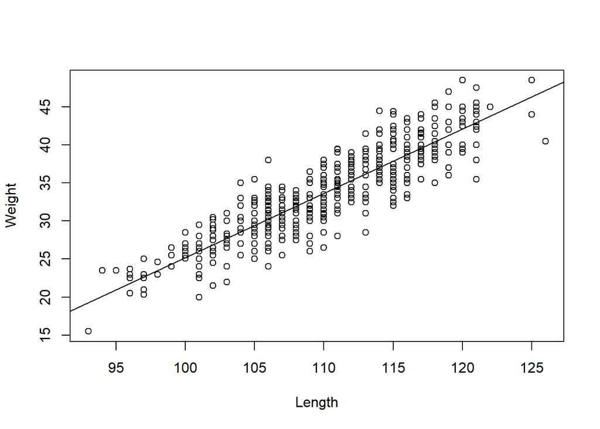

```r
plot(Weight ~ Length, data = SeaLions)
abline(sealion.fit)
```

Note, `abline` is a function that adds an intercept-slope line to any existing plot (“a” - intercept, “b” - slope).

Here are some ways to make this a bit prettier:

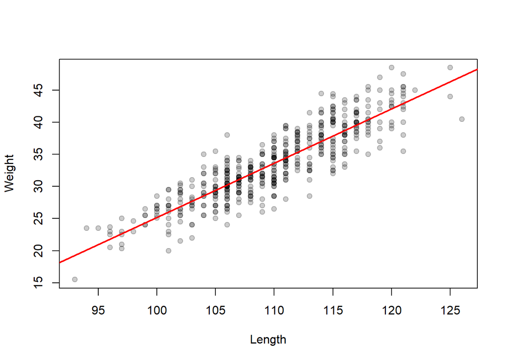

```r
plot(Weight ~ Length, data = SeaLions, pch = 19, col = rgb(0,0,0,.2))
abline(sealion.fit, col = "red", lwd = 2)
```

The `pch = 19` makes filled dots, `col = rgb(0,0,0,.2)` is a way to make transparent black colors, `lwd = 2` is the line thickness, `col = "red"`.

# Lab Exercise 1

> You can subset the data into males and females with the following code:

```r
SeaLion.males <- subset(SeaLions, Sex == "M")
SeaLion.females <- subset(SeaLions, Sex == "F")
```

> Use these subsetted data and:
> 1. Plot the relationship between Weight and Length for each of males and females
> 2. Fit a model and add the regression line to the plot.
> 3. Report the estimate at 95% C.I. of the slope coefficient for males and females. Based on these results, do they have different growth curves?

# Part II: Linear models for exponential growth (WHAT!?)

Load the sea otter data and plot it:

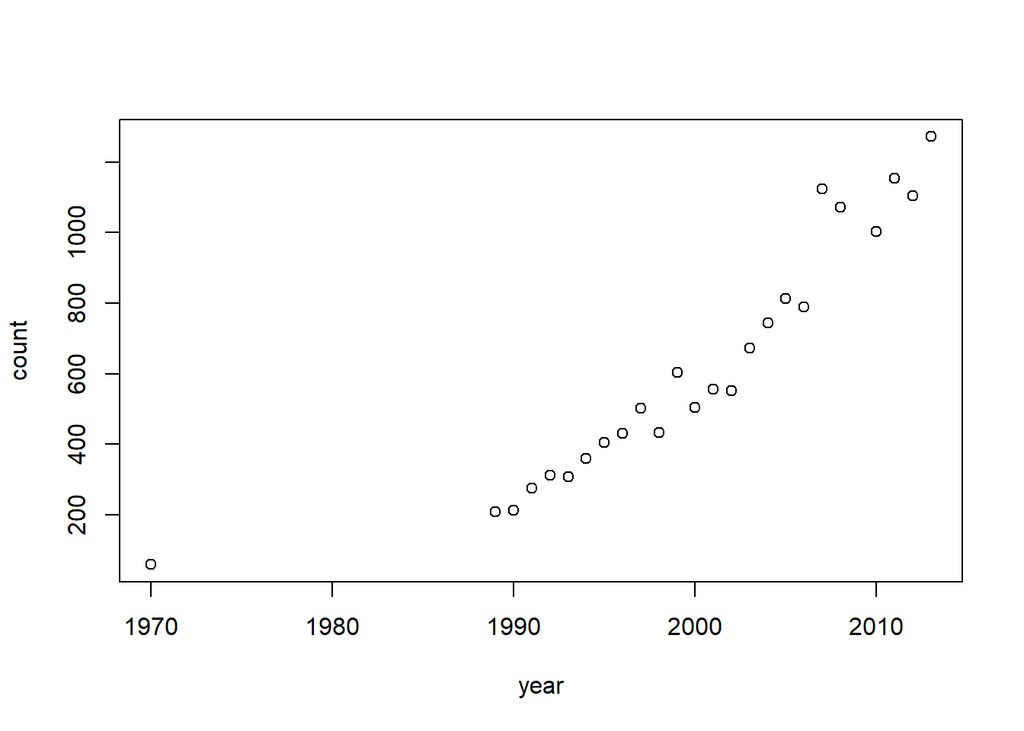

```r
plot(count ~ year, data = SeaOtters)
```

It is quite easy to make plots on a log scale, by the way, which can be useful:

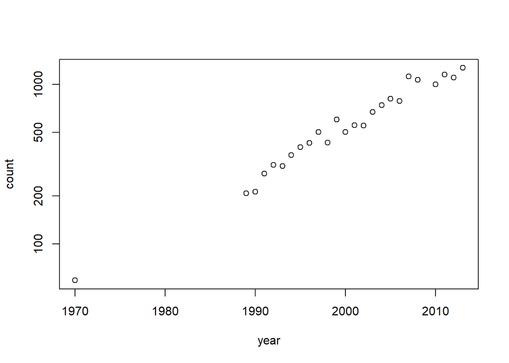

```r
plot(count ~ year, data = SeaOtters, log = "y")
```

## Simple linear Model

```r
otter.fit <- lm(count ~ year, data = SeaOtters)
```

```r
otter.fit
```

```
##
## Call:
## lm(formula = count ~ year, data = SeaOtters)
##
## Coefficients:
## (Intercept)         year
##   -65751.54        33.19
```

Again, there is a lot more information if you ask for a summary:

```r
summary(otter.fit)
```

```
##
## Call:
## lm(formula = count ~ year, data = SeaOtters)
##
## Residuals:
##     Min      1Q  Median      3Q     Max
## -152.74  -78.18  -58.79   34.71  417.48
##
## Coefficients:
##              Estimate Std. Error t value Pr(>|t|)
## (Intercept) -65751.54    6158.81  -10.68 2.19e-10 ***
## year            33.19       3.08   10.78 1.83e-10 ***
## ---
## Signif. codes:  0 '***' 0.001 '**' 0.01 '*' 0.05 '.' 0.1 ' ' 1
##
## Residual standard error: 142.4 on 23 degrees of freedom
## Multiple R-squared:  0.8347, Adjusted R-squared:  0.8275
## F-statistic: 116.1 on 1 and 23 DF,  p-value: 1.83e-10
```

We can plot this linear model on our data:

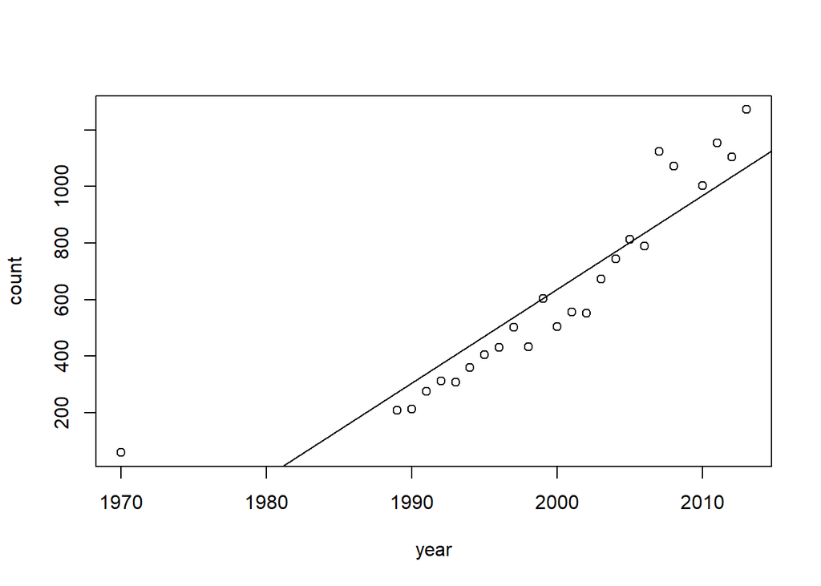

```r
plot(count ~ year, data = SeaOtters)
abline(otter.fit)
```

## Log Transformation

We kind of knew the growth was not linear (otherwise this week’s topic wouldn’t have been called *Exponential Growth*). But how can we use a linear model to fit an exponential growth function?

With a simple transformation!

$$\log(Y_i) = \alpha + \beta\, X_i +
\epsilon_i$$

How does this relate to an exponential growth model?

$$e^{\log(Y_i)} = e^{\alpha + \beta\, X_i
+ \epsilon_i}$$
$$Y_t =
N_0 e^{\beta\, X_t + \epsilon_t}$$

We just replaced $e^\alpha$ with $N_0$, and $i$ with $t$. But $\beta$ is EXACTLY the growth rate $r$ (and $e^\beta = \lambda$). The $\epsilon_i$ hanging on the end is a bit of stochasticity.

Anyways, doing this with our linear modeling tools is easy. We just wrap `count` in a log.

```r
logotter.fit <- lm(log(count) ~ year, data = SeaOtters)
summary(logotter.fit)
```

```
##
## Call:
## lm(formula = log(count) ~ year, data = SeaOtters)
##
## Residuals:
##       Min        1Q    Median        3Q       Max
## -0.191084 -0.062944 -0.005104  0.055518  0.231704
##
## Coefficients:
##               Estimate Std. Error t value Pr(>|t|)
## (Intercept) -1.402e+02  4.732e+00  -29.63   <2e-16 ***
## year         7.325e-02  2.367e-03   30.95   <2e-16 ***
## ---
## Signif. codes:  0 '***' 0.001 '**' 0.01 '*' 0.05 '.' 0.1 ' ' 1
##
## Residual standard error: 0.1094 on 23 degrees of freedom
## Multiple R-squared:  0.9766, Adjusted R-squared:  0.9755
## F-statistic: 958.1 on 1 and 23 DF,  p-value: < 2.2e-16
```

Note how our statistics changed. Specifically: our $\beta$ estimate (which is also $r$) is now 0.07325, which is a good estimate of the intrinsic growth rate. Even better, we know have a standard error around that estimate: 0.00237, which means our growth rate can be written as: $\widehat{r} = (7.32 \pm 0.47)\times 10^{-2}$. We can convert that to an annual growth rate in R as well (*do NOT worry about understanding the following code*:

```r
r.hat <- summary(logotter.fit)$coefficients[2,1]
r.sd <- summary(logotter.fit)$coefficients[2,2]
exp(c(r.hat, r.hat-2*r.sd, r.hat+2*r.sd))
```

```
## [1] 1.076001 1.070920 1.081106
```

So our estimate of annual population growth is 7.6% (95% Confidence Interval 7.1%-8.1%). Note how much higher the $R^2$ value is! This is (by that measure also) a much better fit.

To visualize the fit:

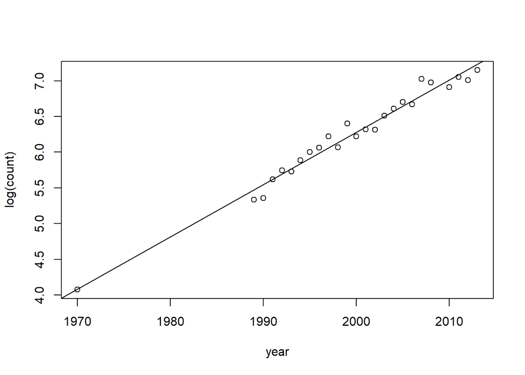

```r
plot(log(count) ~ year, data = SeaOtters)
abline(logotter.fit)
```

Much better!

Let’s make our final graph a little nicer

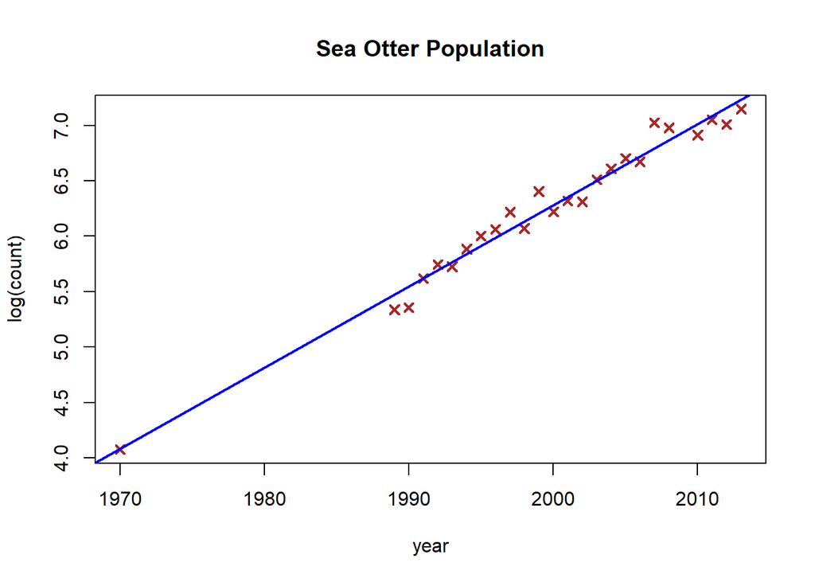

```r
plot(log(count) ~ year, main = 'Sea Otter Population',
     col = 'brown', pch = 4, data = SeaOtters, lwd = 2)
abline(logotter.fit, col = "blue", lwd = 2)
```

The commands we’re using within the `plot` function include setting the title of the graph (`main =`), changing the color of the symbols and the line (`col =`), and changing the shape of the symbols (`pch =`). There also many more alterations you can make to get your graph perfect - but that can be a deep dark `R`abbit hole!

Finally, we can also draw the fit on non-log transformed data as follows:

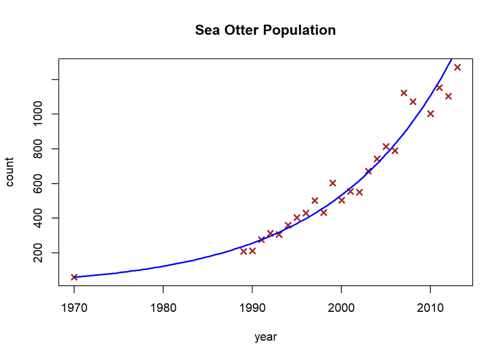

```r
plot(count ~ year, main = 'Sea Otter Population',
     col = 'brown', pch = 4, data = SeaOtters, lwd = 2)
curve(exp(logotter.fit$coef[1] +
            logotter.fit$coef[2] * x), col = "blue", add = TRUE, lwd = 2)
```

# Lab Exercise 2

> In the next homework assignment (due next Thursday, March 2) you will be asked to analyze the population growth rate of sea otters in British Columbia, the population just to the north of Washington state. The data are **here** in a file called `BC_SeaOtters`.

> For the lab exercise **all you need to do** is (1) Load the data, (2) plot the data, and (3) report how many were released, in what year, how many are there in the final year of data.

> In the homework, you will estimate the growth rate with confidence intervals as well, but you don’t need to worry about that for the lab.

**NOTE: You can skip the section below as it is non-essential. But arguably “fun”.**

### More `ggplot` plotting

It can be a bit fussy to plot the confidence interval around our prediction. Below, we include a little snippet of code which does just that using `ggplot`. You do not need to understand this code (there’s actually quite a bit going on to get it to work right), but the output is pretty.

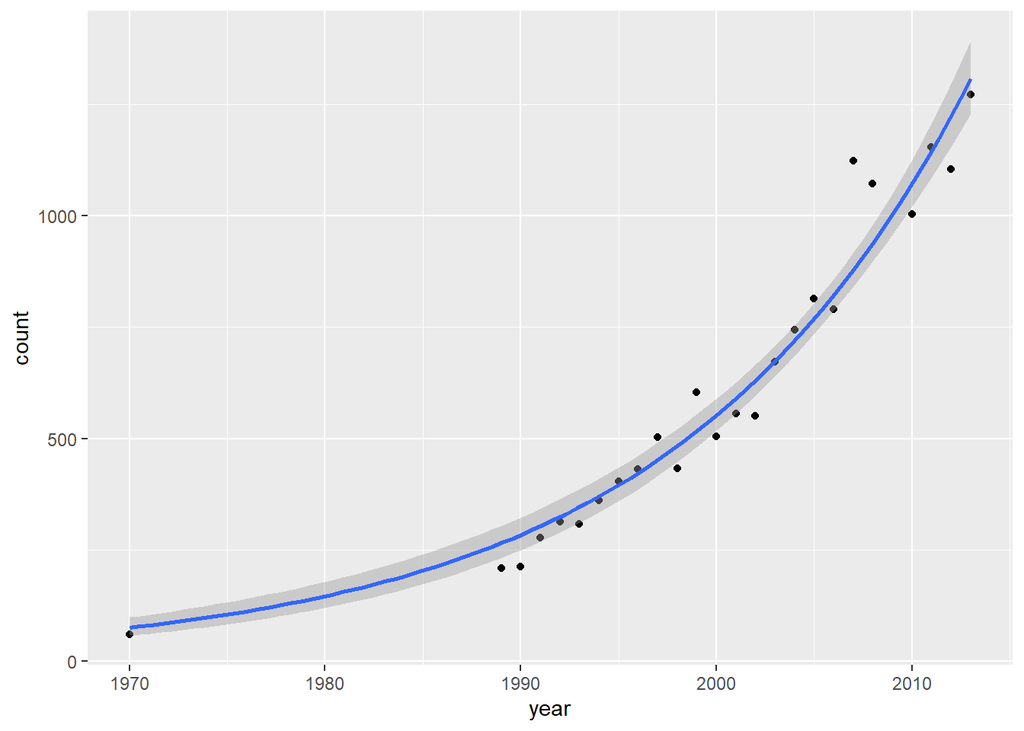

```r
require(ggplot2)

ggplot(SeaOtters, aes(year, count)) + geom_point() +
    stat_smooth(method = "glm",
                method.args = list(family = gaussian(link = "log")))
```

This really looks like a nice fit!

# Lab Exercise 3

> The final exercise is NOT in R! It is just some practice experimneting with the stochastic population simulator here: https://egurarie.shinyapps.io/StochasticGrowth. The goal will be to see how sensitive the sea otter success is to the initial population released.
> 1. In the **Demographic Stochasticity** simulator, change the probability of giving birth to **0.3**, and the probability of dying at **0.2** (these numbers approximate sea otter population growth). Set $t_{max}$ to 40 years. Increase the number of simulations to 1000.  
>    Report the **probability of extinction due to demographic stochasticity** and the **final median population size** if only (a) **2**, (b) **10** and (c) **60** sea otters were released.
> 2. In the **Environmental Stochasticity** simulater, set the **mean population growth rate** ($\mu_r$) to 1, the $t_{max}$ to 40, the **number of otters released** ($N_0$) to 60, and the number of simulations to 1000. Again, this (very) roughly simulates sea otter population growth.  
>    Report the **probability of extinction due to environmental stochasticity** and the **final median population size** if the **standard deviation on the growth rate** ($\sigma_r$) varies between: (a) **0.05**, (b) **0.1**, (c) **1**, and (d) **2**.